```python
import pandas as pd
import numpy as np
import seaborn as sns
import matplotlib.pyplot as plt
from pandas.plotting import scatter_matrix
```

```python
df1=pd.read_csv(r'C:\Users\kacpr\OneDrive - Akademia Górniczo-Hutnicza im. Stanisława Staszica w Krakowie\Licencjat\Dane\otomoto_offers_eng_23-04-2023.csv',delimiter=';')
```

# Transformacje

## usunięcie nadmiarowych kolumn

```python
df1.shape
```

```
(208205, 243)
```

Dane posiadają 208 tysięcy rekordów oraz 243 kolumny.

```python
df2=df1.iloc[:,0:30].copy()
```

```python
df2.columns
```

```
Index(['id', 'offer_creation_date', 'offer_title', 'price', 'currency',
       'seller_type', 'seller_registration_year', 'location', 'offer_from',
       'category', 'show_offers_with_vin_number', 'vehicle_brand',
       'vehicle_model', 'generation', 'production_year', 'mileage',
       'engine_displacement', 'fuel_type', 'power', 'transmission',
       'body_type', 'number_of_doors', 'number_of_seats', 'color',
       'vat_margin', 'financing_possibility', 'state', 'version',
       'fuel_consumption_in_city', 'color_type'],
      dtype='object')
```

Teraz zajmę się oczyszczaniem tych kolumn. Najpierw dodam kolumny, które będą mi potrzebne do oczyszczenia danych:

```python
df3= pd.concat([df2, df1[['drive_type','no_accident','damaged']]], axis=1)
```

Te kolumny usuwam, ponieważ są zbędne do naszego modelu.

```python
df3=df3.drop(['vat_margin','financing_possibility','offer_creation_date','offer_title','fuel_consumption_in_city','show_offers_with_vin_number','location','version','drive_type','seller_registration_year','number_of_doors', 'number_of_seats', 'color','color_type','generation'],axis=1).copy()
```

## lista wybranych kolumn

```python
df3.columns
```

```
Index(['id', 'price', 'currency', 'seller_type', 'offer_from', 'category',
       'vehicle_brand', 'vehicle_model', 'production_year', 'mileage',
       'engine_displacement', 'fuel_type', 'power', 'transmission',
       'body_type', 'state', 'no_accident', 'damaged'],
      dtype='object')
```

## Czyszczenie i edycja danych

1. Zmienna 'price' jest w różnych walutach. Zmienię ją na walute PLN

```python
df3['price'] = df3['price'].astype(float)
df3.loc[df3['currency'] == 'EUR', 'price'] *= 4.29
df3=df3.drop('currency',axis=1)
```

2. Nasze badanie opiera się na samochodach używanych, więc usunę wszystkie nowe samochodu. Cena nowego samochodu może zaburzać nasze modele.

```python
filt=(df3['state']=='New')
len(df3[filt])
df3 = df3.loc[~filt]
```

20 690 samochodów w naszych danych jest oznaczone jako nowe. Usuwamy je z naszej bazy

```python
filt=(df3['no_accident']=='Tak')
df3=df3.loc[~filt]

filt=(df3['damaged']=='Tak')
df3=df3.loc[~filt]
len(df3)
```

```
79564
```

po usunięciu zbędnych wiersz zostaje nam 80 tysięcy rekordów

4. Usuwanie miar (moc,pojemnosc silnika,przebieg)

```python
df3['mileage'] = df3['mileage'].str.replace(' km','').str.replace(' ','').astype(float)
df3['engine_displacement'] = df3['engine_displacement'].str.replace(' cm3','').str.replace(' ','.').astype(float)
df3['power'] = df3['power'].str.replace(' KM','').str.replace(' ','').astype(float)
```

5. zmiana kolumny production_year na liczbę wieku samochodu (przyjmuję 2023 jako rok, poniewaz dane są z tego roku)

```python
df3['car_age'] = df3['production_year'].apply(lambda x: 2023 - x)
df3=df3.drop('production_year',axis=1)
```

## Podsumowanie czyszczenia i transformacji danych

1. Pozbyłem się większości kolumn które zawierały informację czy samochód np. ma elektryczne szyby czy nie (TRUE/FALSE)
2. Pozbyłem się potem kolejnych kolumn, które wydawały się zbędnę np. kolor, lokalizacja
3. Zmieniłem wszystkie ceny na jedną walutę
4. Usunąłem z danych pojazdy oznaczone jako nowe
5. Usunąłem pojazdy oznaczone jako 'damaged' albo 'accident'
6. Wyczyściłem zmienne liczbowe z miar
7. Stworzyłem kolumnę 'car_age'

# Sprawdzenie wartości brakujących i odstających

```python
df4=df3.loc[:,['price','seller_type','vehicle_brand','vehicle_model','car_age','mileage','engine_displacement',
       'fuel_type', 'power', 'transmission', 'body_type']]
```

```python
df4.isnull().values.any()
```

```
np.True_
```

```python
filt=(df4['fuel_type']=='Electric') | (df4['fuel_type']=='Hyrdrogen')
```

```python
df4.loc[filt]
```

|  | price | seller_type | vehicle_brand | vehicle_model | car_age | mileage | engine_displacement | fuel_type | power | transmission | body_type |
| --- | --- | --- | --- | --- | --- | --- | --- | --- | --- | --- | --- |
| 26 | 73500.0 | Private person | BMW | i3 | 9 | 32000.0 | NaN | Electric | 170.0 | Automatic | Compact |
| 456 | 184900.0 | Private person | Tesla | Model S | 8 | 206000.0 | NaN | Electric | 378.0 | Automatic | Compact |
| 588 | 64999.0 | Private person | Renault | Twingo | 2 | 6800.0 | NaN | Electric | 82.0 | Automatic | Small cars |
| 944 | 105900.0 | Dealer | Nissan | Leaf | 4 | 28908.0 | NaN | Electric | 150.0 | Automatic | City cars |
| 1008 | 50000.0 | Private person | Nissan | Leaf | 7 | 95000.0 | NaN | Electric | 109.0 | Automatic | City cars |
| ... | ... | ... | ... | ... | ... | ... | ... | ... | ... | ... | ... |
| 205305 | 122600.0 | Private person | Hyundai | Kona | 2 | 44000.0 | NaN | Electric | 204.0 | Automatic | SUV |
| 205885 | 179900.0 | Dealer | Tesla | Model 3 | 3 | 49500.0 | NaN | Electric | 512.0 | Automatic | Sedan |
| 206734 | 184999.0 | Dealer | Tesla | Model 3 | 3 | 69000.0 | NaN | Electric | 497.0 | Automatic | Sedan |
| 207639 | 74900.0 | Private person | Renault | Zoe | 5 | 23200.0 | NaN | Electric | 109.0 | Automatic | Compact |
| 207806 | 143000.0 | Private person | Hyundai | Kona | 3 | 33000.0 | NaN | Electric | 204.0 | Automatic | SUV |

508 rows × 11 columns

z uwagi na fakt, że samochody elektryczne i na wodór nie posiadają pojemności silnika (zmienna engine_displacement) oraz na fakt, że korelacja z ceną jest bardzo słaba (0.03) to usuwam kolumnę engine_displacement

```python
df4=df4.drop('engine_displacement',axis=1)
```

```python
df4.isnull().values.any()
```

```
np.True_
```

```python
new_data = df4.dropna(axis=0, how='any')
```

```python
((len(df4)-len(new_data))/len(df4))*100
```

```
0.03142124578955306
```

Około 0.03 % danych miało jakieś wartości brakujące. Z uwagi na fakt, że jest to bardzo mała liczba to usuwam całe wiersze z danych

```python
df4=new_data.copy()
```

### Wartosci odstające

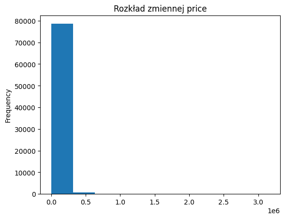

```python
df4['price'].plot.hist()
plt.title('Rozkład zmiennej price')
```

Pytanie - czy powinienem przekształcić zmienną price logarytmem? Z uwagi na fakt, że jest bardzo duża prawa skośność i praktycznie całość danych znajduje się w przedziale 0-250 tysięcy. Po nałożeniu logarytmu na cene wykres wygląda tak:

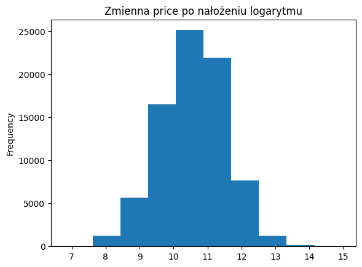

```python
np.log(df4['price']).plot.hist()
plt.title('Zmienna price po nałożeniu logarytmu')
df4_log=df4.copy()
df4_log['price']=np.log(df4_log['price'])
```

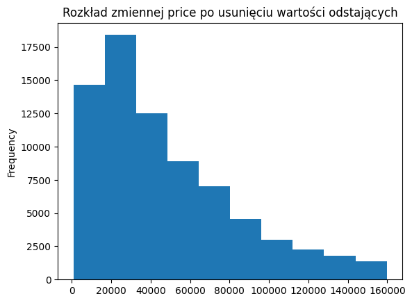

```python
data = sorted(df4['price'])
q1 = np.percentile(data, 25)
q3 = np.percentile(data, 75)
IQR = q3-q1
lwr_bound = q1-(1.5*IQR)
upr_bound = q3+(1.5*IQR)
filt = (df4['price'] < lwr_bound) | (df4['price'] > upr_bound)
df4=df4.loc[~filt]
df4['price'].plot.hist()
plt.title('Rozkład zmiennej price po usunięciu wartości odstających')
```

Jak widzimy, usuwając wartości odstające zmienna price teraz ma maksymalną wartość w okolicach 160 tysięcy. Dane mają 74 tysiące rekordów, więc około 5 tysięcy danych zostało usuniętych

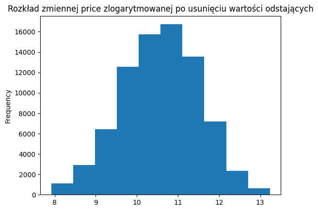

```python
data = sorted(df4_log['price'])
q1 = np.percentile(data, 25)
q3 = np.percentile(data, 75)
IQR = q3-q1
lwr_bound = q1-(1.5*IQR)
upr_bound = q3+(1.5*IQR)
filt = (df4_log['price'] < lwr_bound) | (df4_log['price'] > upr_bound)
df4_log=df4_log.loc[~filt]
df4_log['price'].plot.hist()
plt.title('Rozkład zmiennej price zlogarytmowanej po usunięciu wartości odstających')
```

W przypadku usunięciu wartości odstających dla zmiennej zlogarytmowanej 'price' usuneliśmy tylko 500 obserwacji, czyli o 10 razy mniej niż w przypadku braku logarytmu

### Wybranie 15 najliczniejszych producentów

mamy 87 producentów samochodów, lecz w moim badaniu skupię się na 15 najliczniejszych

```python
list=df4['vehicle_brand'].value_counts().head(15).sort_values(ascending=False)
```

```python
filt=df4['vehicle_brand'].isin(list.index)
```

```python
df5=df4.loc[filt]
```

```python
len(df5)
```

```
59426
```

Zmiana na kategoryczne zmienne

```python
categorical_columns = ['seller_type', 'vehicle_brand', 'fuel_type','vehicle_model', 'transmission', 'body_type']
df5[categorical_columns] = df5[categorical_columns].astype('category')
```

## Podsumowanie usuwania braków i wartości odstających

# EDA i korelacje

```
array([[<Axes: xlabel='price', ylabel='price'>,
        <Axes: xlabel='car_age', ylabel='price'>,
        <Axes: xlabel='mileage', ylabel='price'>,
        <Axes: xlabel='power', ylabel='price'>],
       [<Axes: xlabel='price', ylabel='car_age'>,
        <Axes: xlabel='car_age', ylabel='car_age'>,
        <Axes: xlabel='mileage', ylabel='car_age'>,
        <Axes: xlabel='power', ylabel='car_age'>],
       [<Axes: xlabel='price', ylabel='mileage'>,
        <Axes: xlabel='car_age', ylabel='mileage'>,
        <Axes: xlabel='mileage', ylabel='mileage'>,
        <Axes: xlabel='power', ylabel='mileage'>],
       [<Axes: xlabel='price', ylabel='power'>,
        <Axes: xlabel='car_age', ylabel='power'>,
        <Axes: xlabel='mileage', ylabel='power'>,
        <Axes: xlabel='power', ylabel='power'>]], dtype=object)
```

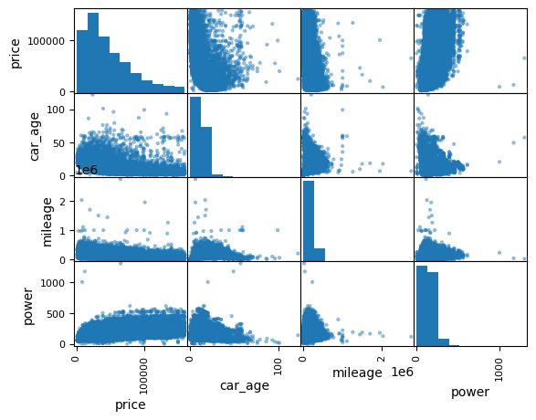

```python
scatter_matrix(df5)
```

### auta powyzej 50 lat

```python
filt=df5['car_age']>50
df5.loc[filt].head()
```

|  | price | seller_type | vehicle_brand | vehicle_model | car_age | mileage | fuel_type | power | transmission | body_type |
| --- | --- | --- | --- | --- | --- | --- | --- | --- | --- | --- |
| 4835 | 100000.0 | Private person | Ford | Inny | 99 | 999999.0 | Gasoline | 21.0 | Manual | City cars |
| 8376 | 25500.0 | Dealer | BMW | Inny | 51 | 69000.0 | Gasoline | 86.0 | Manual | Coupe |
| 10636 | 69000.0 | Dealer | Ford | Mustang | 58 | 111111.0 | Gasoline | 225.0 | Automatic | Coupe |
| 11247 | 18990.0 | Private person | Mercedes-Benz | Inny | 55 | 68000.0 | Diesel | 80.0 | Manual | Sedan |
| 11939 | 65000.0 | Dealer | Volvo | Inny | 56 | 73500.0 | Gasoline | 90.0 | Manual | Coupe |

### Auta z najwiekszym przebiegiem

```python
df5.sort_values(by='mileage',ascending=False).head()
```

|  | price | seller_type | vehicle_brand | vehicle_model | car_age | mileage | fuel_type | power | transmission | body_type |
| --- | --- | --- | --- | --- | --- | --- | --- | --- | --- | --- |
| 122776 | 65000.0 | Private person | Volkswagen | Touran | 6 | 2750000.0 | Diesel | 115.0 | Automatic | Minivan |
| 3806 | 7999.0 | Private person | Ford | Focus | 17 | 2030000.0 | Gasoline | 125.0 | Manual | Small cars |
| 74952 | 101000.0 | Private person | Renault | Koleos | 6 | 1950001.0 | Diesel | 177.0 | Automatic | SUV |
| 52720 | 20000.0 | Private person | Mercedes-Benz | Klasa E | 18 | 1700000.0 | Gasoline | 163.0 | Automatic | Sedan |
| 6640 | 32500.0 | Private person | Mercedes-Benz | Sprinter | 17 | 1500000.0 | Diesel | 184.0 | Manual | Minivan |

### Czy przebieg zależy od wieku auta?

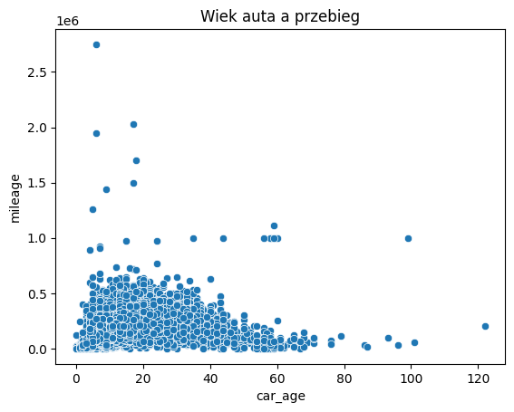

```python
plt.figure()
sns.scatterplot(x=df5['car_age'],y=df5['mileage'])
plt.title('Wiek auta a przebieg')
plt.show()
```

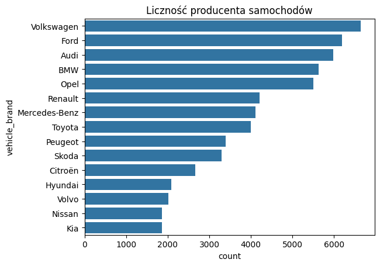

```python
plt.figure()
sns.countplot(y=df5['vehicle_brand'],order=list.index)
plt.title('Liczność producenta samochodów')
```

## Czy cena zależy od marki auta?

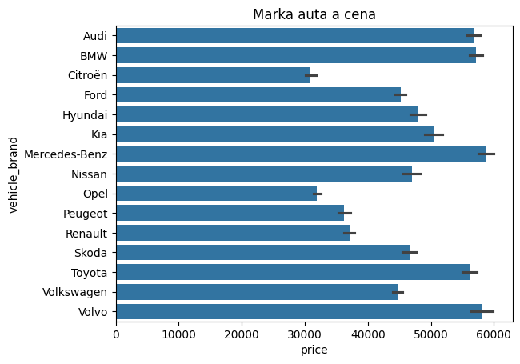

```python
plt.figure()
sns.barplot(x=df5['price'], y=df5['vehicle_brand'], orient='h')
plt.title('Marka auta a cena')
plt.show()
```

Najdroższymi markami są: Volvo, Audi, BMW i Mercedes-Benz, czyli samochody klasy 'premium'. Najtańsze marki to Opel i Citroen.

## Typ paliwa

```python
df5['fuel_type'].value_counts()
```

```
fuel_type
Diesel            29375
Gasoline          25969
Gasoline + LPG     2471
Hybrid             1354
Electric            223
Gasoline + CNG       33
Hydrogen              1
Name: count, dtype: int64
```

z racji że w danych znajduje się tylko jeden samochód o napędzie wodorowym to pozbędziemy się go

```python
filt=(df5['fuel_type']=='Hydrogen')
df5=df5.loc[~filt]
```

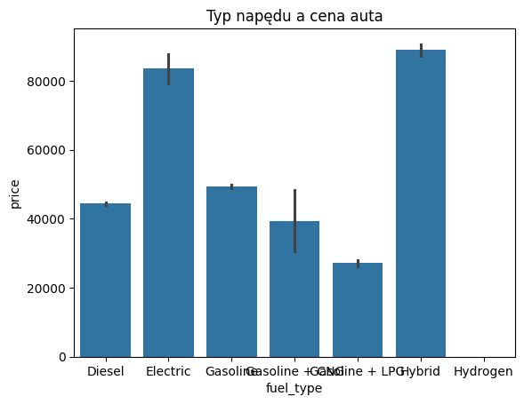

```python
plt.figure()
sns.barplot(x=df5['fuel_type'],y=df5['price'])
plt.title('Typ napędu a cena auta')
plt.show()
```

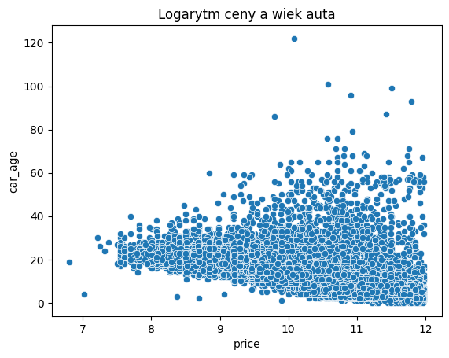

```python
plt.figure()
sns.scatterplot(x=np.log(df5['price']),y=df5['car_age'])
plt.title('Logarytm ceny a wiek auta')
plt.show()
```

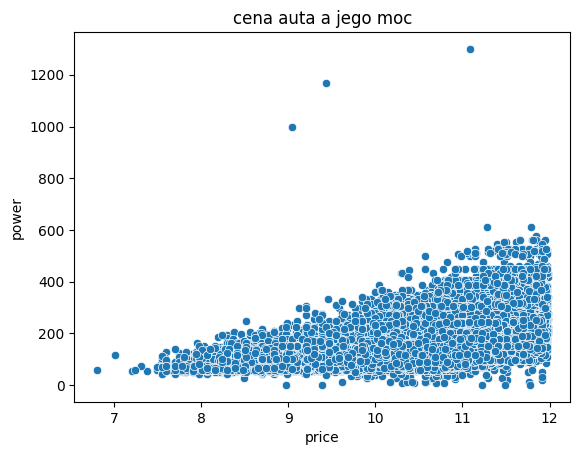

```python
plt.figure()
sns.scatterplot(x=np.log(df5['price']),y=df5['power'])
plt.title('cena auta a jego moc')
plt.show()
```

## Macierze korelacji

Usuwam z macierzy kolumnę vehicle_model, gdyż po analizie korelacji raczej inne cechy są dominujące a model samochodu nie ma wielkiego wpływu na cenę (bardziej marka, dlatego markę zostawiam w badaniu)

```python
df6=df5.drop('vehicle_model',axis=1)
```

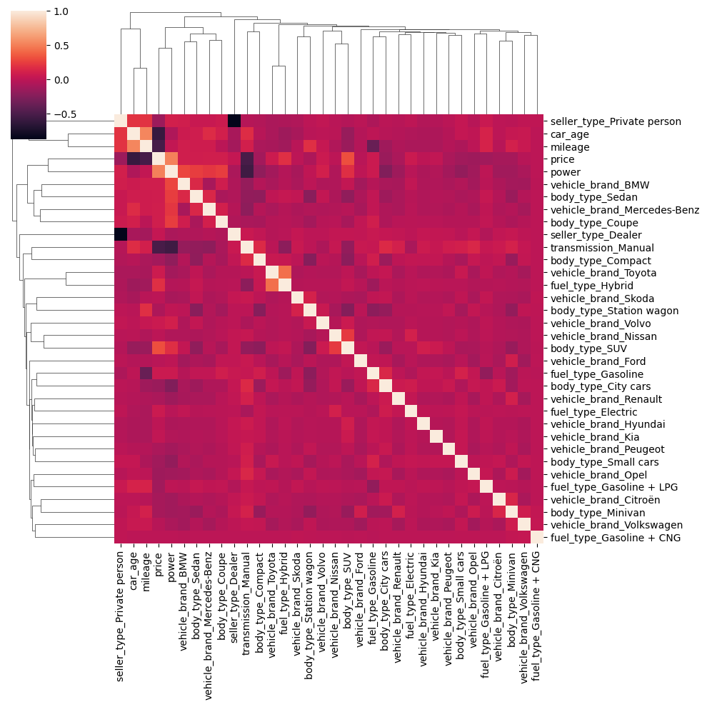

```python
df6_dummies = pd.get_dummies(df5.drop('vehicle_model',axis=1), drop_first=True)
df6_dummies=df6_dummies.drop('fuel_type_Hydrogen',axis=1)
sns.clustermap(df6_dummies.corr())
```

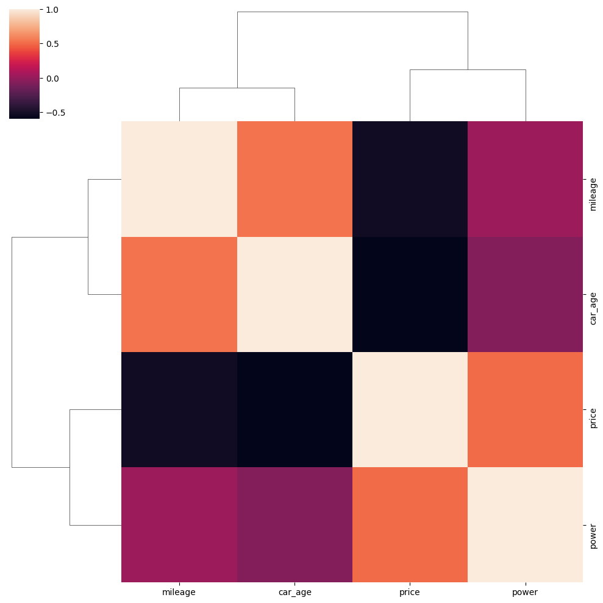

```python
sns.clustermap(df6[['price','power','mileage','car_age']].corr())
```

## Podsumowanie rozdziału EDA i korelacje

1. Na początku przedstawiłem kilka wykresów. Będzie ich więcej w późniejszym etapie.
2. Okazało się, że w naszych danych jest tylko jedno auto na wodór, więc je usuwam
3. Przeprowadzona analiza korelacji - usunięcie kolumny model auta, gdyż jest to zbytnie zagłebianie się w szczegóły a korelacje nie są znaczące

# Skalowanie cech numerycznych

Z racji, że nasze zmienne są w różnej skali to przeskaluje je poprzez standard scaler (x-u)/s

```python
from sklearn.compose import ColumnTransformer
from sklearn.datasets import fetch_openml
from sklearn.pipeline import Pipeline
from sklearn.impute import SimpleImputer
from sklearn.preprocessing import StandardScaler, OneHotEncoder
from sklearn.linear_model import LogisticRegression
from sklearn.model_selection import train_test_split, GridSearchCV
numeric_features = ['car_age','mileage','power']
numeric_transformer = Pipeline(steps=[
    ('scaler', StandardScaler())])

categorical_features = ['seller_type', 'vehicle_brand', 'fuel_type','transmission', 'body_type']
categorical_transformer = OneHotEncoder(handle_unknown='ignore')

preprocessor = ColumnTransformer(
    transformers=[
        ('num', numeric_transformer, numeric_features),
        ('cat', categorical_transformer, categorical_features)])
```

# Regresja liniowa

```python
from sklearn.linear_model import LinearRegression
from sklearn.metrics import mean_absolute_error
clf = Pipeline(steps=[('preprocessor', preprocessor),
                      ('regg', LinearRegression())])

y = df6['price']
X = df6.drop('price', axis=1)


X_train, X_test, y_train, y_test = train_test_split(X, y, test_size=0.2,
                                                    random_state=0)
```

Wynik regresji liniowej:

```python
clf.fit(X_train, y_train)
print("model score: %.3f" % clf.score(X_test, y_test))
```

```
model score: 0.749
```

Wynik regresji liniowej (MAE):

```python
y_pred=clf.predict(X_test)
mean_absolute_error(y_pred,y_test)
```

```
11935.197527251581
```

### Z logarytmem na y

```python
df4_log=df4_log.drop(['vehicle_model'],axis=1)
clf = Pipeline(steps=[('preprocessor', preprocessor),
                      ('regg', LinearRegression())])

y = df4_log['price']
X = df4_log.drop('price', axis=1)


X_train, X_test, y_train, y_test = train_test_split(X, y, test_size=0.2,
                                                    random_state=0)
```

Wynik regreji linowej (logarytm na y):

```python
clf.fit(X_train, y_train)
print("model score: %.3f" % clf.score(X_test, y_test))
```

```
model score: 0.774
```

# Lassso

```python
from sklearn.linear_model import Lasso
clf = Pipeline(steps=[('preprocessor', preprocessor),
                      ('regg', Lasso())])

y = df6['price']
X = df6.drop('price', axis=1)


X_train, X_test, y_train, y_test = train_test_split(X, y, test_size=0.2,
                                                    random_state=0)

clf.fit(X_train, y_train)
print("model score: %.3f" % clf.score(X_test, y_test))
```

```
model score: 0.749
```

# GradientBoosting

```python
from sklearn.ensemble import GradientBoostingRegressor
clf = Pipeline(steps=[('preprocessor', preprocessor),
                      ('regg', GradientBoostingRegressor())])
y = df6['price']
X = df6.drop('price', axis=1)


X_train, X_test, y_train, y_test = train_test_split(X, y, test_size=0.2,
                                                    random_state=0)
```

Wynik GradientBoosting:

```python
clf.fit(X_train, y_train)
print("model score: %.3f" % clf.score(X_test, y_test))
```

```
model score: 0.884
```

Wynik GradientBoosting(MAE):

```python
y_pred=clf.predict(X_test)
mean_absolute_error(y_pred,y_test)
```

```
7893.650754728626
```

### z logarytmem

```python
clf = Pipeline(steps=[('preprocessor', preprocessor),
                        ('regg', GradientBoostingRegressor())])

y = df4_log['price']
X = df4_log.drop('price', axis=1)


X_train, X_test, y_train, y_test = train_test_split(X, y, test_size=0.2,
                                                    random_state=0)
```

Wynik GradientBoosting(logarytm na y):

```python
clf.fit(X_train, y_train)
print("model score: %.3f" % clf.score(X_test, y_test))
```

```
model score: 0.898
```

# Decision Tree

```python
from sklearn.tree import DecisionTreeRegressor
clf = Pipeline(steps=[('preprocessor', preprocessor),
                      ('regg', DecisionTreeRegressor())])
y = df6['price']
X = df6.drop('price', axis=1)


X_train, X_test, y_train, y_test = train_test_split(X, y, test_size=0.2,
                                                    random_state=0)
```

Wynik decision tree:

```python
clf.fit(X_train, y_train)
print("model score: %.3f" % clf.score(X_test, y_test))
```

```
model score: 0.842
```

Wynik decision tree (MAE):

```python
y_pred=clf.predict(X_test)
mean_absolute_error(y_pred,y_test)
```

```
8546.915064647314
```

### z logarytmem

```python
clf = Pipeline(steps=[('preprocessor', preprocessor),
                       ('regg', DecisionTreeRegressor())])

y = df4_log['price']
X = df4_log.drop('price', axis=1)


X_train, X_test, y_train, y_test = train_test_split(X, y, test_size=0.2,
                                                    random_state=0)
```

Wynik decision tree (logarytm na y):

```python
clf.fit(X_train, y_train)
print("model score: %.3f" % clf.score(X_test, y_test))
```

```
model score: 0.862
```

# MLP

```python
from sklearn.neural_network import MLPRegressor
from sklearn.metrics import mean_absolute_error
clf = Pipeline(steps=[('preprocessor', preprocessor),
                      ('regg', MLPRegressor())])
y = df6['price']
X = df6.drop('price', axis=1)


X_train, X_test, y_train, y_test = train_test_split(X, y, test_size=0.2,
                                                    random_state=0)
```

Wynik MLP:

```python
clf.fit(X_train, y_train)
print("model score: %.3f" % clf.score(X_test, y_test))
```

```
model score: 0.861
```

Wynik MLP (MAE):

```python
y_pred=clf.predict(X_test)
mean_absolute_error(y_pred,y_test)
```

```
8204.536021618318
```

### z logarytmem

```python
clf = Pipeline(steps=[('preprocessor', preprocessor),
                       ('regg', MLPRegressor())])

y = df4_log['price']
X = df4_log.drop('price', axis=1)


X_train, X_test, y_train, y_test = train_test_split(X, y, test_size=0.2,
                                                    random_state=0)
```

Wynik MLP (logarytm na y):

```python
clf.fit(X_train, y_train)
print("model score: %.3f" % clf.score(X_test, y_test))
```

```
model score: 0.919
```

# XGBOOST

```python
import xgboost as xgb
xgb_model=xgb.XGBRegressor(objective='reg:linear')
clf = Pipeline(steps=[('preprocessor', preprocessor),
                      ('regg', xgb.XGBRegressor(objective='reg:squarederror', eval_metric='mae'))])
y = df6['price']
X = df6.drop('price', axis=1)

X_train, X_test, y_train, y_test = train_test_split(X, y, test_size=0.2, random_state=0)
```

Wynik XGBoost:

```python
clf.fit(X_train, y_train)
print("model score: %.3f" % clf.score(X_test, y_test))
```

```
model score: 0.912
```

Wynik XGBoost (MAE):

```python
y_pred=clf.predict(X_test)
mean_absolute_error(y_pred,y_test)
```

```
6522.510155354579
```

### Z logarytmem

```python
clf = Pipeline(steps=[('preprocessor', preprocessor),
                       ('regg', xgb.XGBRegressor(objective='reg:squarederror', eval_metric='mae'))])

y = df4_log['price']
X = df4_log.drop('price', axis=1)


X_train, X_test, y_train, y_test = train_test_split(X, y, test_size=0.2,
                                                    random_state=0)
```

Wynik XGBoost (logarytm na y):

```python
clf.fit(X_train, y_train)
print("model score: %.3f" % clf.score(X_test, y_test))
```

```
model score: 0.922
```

# Tensorflow

```python
import tensorflow as tf

from tensorflow import keras
from tensorflow.keras import layers
from sklearn.metrics import r2_score
```

```python
model = keras.Sequential([
    layers.Dense(64, activation='relu'),
    layers.Dense(64, activation='relu'),
    layers.Dense(1)
])

model.compile(
    optimizer=tf.keras.optimizers.Adam(0.001),
    loss='mean_absolute_error')
```

```python
numeric_features = ['car_age','mileage','power']
numeric_transformer = Pipeline(steps=[
    ('scaler', StandardScaler())])

categorical_features = ['seller_type', 'vehicle_brand', 'fuel_type','transmission', 'body_type']
categorical_transformer = OneHotEncoder(handle_unknown='ignore')

preprocessor = ColumnTransformer(
    transformers=[
        ('num', numeric_transformer, numeric_features),
        ('cat', categorical_transformer, categorical_features)])

y = df6['price']
X = df6.drop('price', axis=1)


X_train, X_test, y_train, y_test = train_test_split(X, y, test_size=0.2,
                                                    random_state=0)

X_train=preprocessor.fit_transform(X_train)
X_test=preprocessor.fit_transform(X_test)
```

```python
# Fit the model
history = model.fit(
    X_train,
    y_train,
    epochs=200,
    # Suppress logging.
    verbose=0
)
```

Wynik seci neuronowej (tensorflow):

```python
y_predict=model.predict(X_test)
mean_absolute_error(y_predict,y_test)
r2_score(y_predict,y_test)
```

```
372/372 ━━━━━━━━━━━━━━━━━━━━ 1s 3ms/step
```

```
0.8925214337818306
```

# Podsumowanie wyników modeli

1. Regresja liniowa uzyskała skuteczność na poziomie 0.75 (z logarytmem na y 0.77)
2. Model GradientBoosting uzyskał 0.88 (z logarytmem na y 0.89)
3. Model Decision Tree uzyskał 0.84 (z logarytmem na y 0.86)
4. Model MLP uzyskał 0.86 (z logarytmem na y 0.92)
5. Model XGBoost uzyskał 0.91 (z logarytmem na y 0.92)
6. Model sieci neuronowej(z biblioteki tensorflow) uzyskał 0.89

# Pytania

1. Czy sposób wyboru przeze mnie kolumn trzeba jakoś uzasadnić?
2. Czy w pracy muszę sekwencyjnie opisywać dlaczego odrzuciłem jakieś zmienne? Chodzi mi o to, czy jeśli np odrzucę na początku 5 kolumn i pójdę z analizą dalej i okaże się, że jeszcze jakaś jedna kolumna jest zbędna to czy napisać że odrzucam ją w tym momencie, czy lepiej cofnąć się do momentu gdy odrzucałem 5 kolumn i tam ją usunąć i napisać np. że odrzucam też 6 bo już wiem że ona będzie zła?
3. Czy mogę zastosować logarytm na y? Wiem że prowadzi to do problemów z interpretacją wyników, ale same wyniki modeli okazały się troszkę lepsze. Dodatkowo usuwaliśmy w ten sposób dużo mniej wartości odstających, więc dane są bardziej pełne.
4. Może zastosować jakieś inne przekształcenie niż logarytm na y?
5. Jeśli chodzi o korelacje - korelacja między ceną samochodu, a marką jest niewielka (max ok 0.1), lecz wydaje mi się to dosyć ważnym czynnikiem (plus korelacja może nie być liniowa). Czy mogę zostawić te kolumny z marką mimo że ta korelacja jest niewielka?
6. Czy przeprowadzić głębszą analizę regresji liniowej? Chodzi mi tutaj o sprawdzenie założeń, sprawdzenia wartości odstających (np. metodą Cooka), sprawdzenie współliniowości i doborze zmiennych poprzez kryterium np. AIC?
7. Czy jeszcze dodałby Pan Doktor jakieś inne modele? Co jeszcze mogę dodać do mojej pracy? Pamiętam, że rozmawialiśmy o shap'ie.
8. Myślę, że pracę podziele na 3 główne rozdziały - wstęp teoretyczny(opis rynku samchodów używanych w Polsce, EDA moich dancyh), Opisy użytych modeli(czyli trochę teorii o każdym modelu), Porównanie skuteczności modeli(czyli tabela z wynikami i tutaj opisuję który model poradził sobie najlepiej, może ten shap?, jakieś podsumowanie pracy). Czy to będzie okej?